### Table 2.2.1 Global and regional estimates of TB mortality, numbers (in thousands) and rates (per 100 000 population) in 2020

| Region or country group | Number of deaths (in thousands) HIV-negative Best estimate | Number of deaths (in thousands) HIV-negative Low | Number of deaths (in thousands) HIV-negative High | Number of deaths (in thousands) HIV-positive Best estimate | Number of deaths (in thousands) HIV-positive Low | Number of deaths (in thousands) HIV-positive High | Rate per 100 000 population HIV-negative Best estimate | Rate per 100 000 population HIV-negative Low | Rate per 100 000 population HIV-negative High | Rate per 100 000 population HIV-positive Best estimate | Rate per 100 000 population HIV-positive Low | Rate per 100 000 population HIV-positive High |
| --- | --- | --- | --- | --- | --- | --- | --- | --- | --- | --- | --- | --- |
| African Region | 379 | 321 | 441 | 170 | 144 | 199 | 34 | 29 | 39 | 15 | 13 | 18 |
| Region of the Americas | 19 | 18 | 20 | 7.9 | 7.2 | 8.7 | 1.9 | 1.8 | 2.0 | 0.77 | 0.70 | 0.85 |
| Eastern Mediterranean Region | 80 | 68 | 92 | 2.9 | 2.5 | 3.3 | 11 | 9.3 | 13 | 0.39 | 0.34 | 0.46 |
| European Region | 21 | 20 | 22 | 5.4 | 5.0 | 5.9 | 2.3 | 2.2 | 2.4 | 0.58 | 0.53 | 0.63 |
| South-East Asia Region | 698 | 650 | 747 | 21 | 19 | 23 | 35 | 32 | 37 | 1.1 | 0.96 | 1.1 |
| Western Pacific Region | 87 | 80 | 93 | 5.9 | 4.9 | 6.9 | 4.5 | 4.1 | 4.8 | 0.30 | 0.25 | 0.36 |
| High TB burden countries | 1 110 | 1 030 | 1 190 | 166 | 139 | 194 | 23 | 22 | 25 | 3.4 | 2.9 | 4.0 |
| Global | 1 280 | 1 210 | 1 360 | 214 | 187 | 242 | 17 | 16 | 18 | 2.7 | 2.4 | 3.1 |

Low and high are the 5th and 95th percentiles of the uncertainty interval (UI)

### Fig. 2.2.1 Global trends in the estimated number of TB deaths (left) and the mortality rate (right), 2000–2020

Shaded areas represent uncertainty intervals. The horizontal dashed line shows the 2020 milestone of the End TB Strategy.

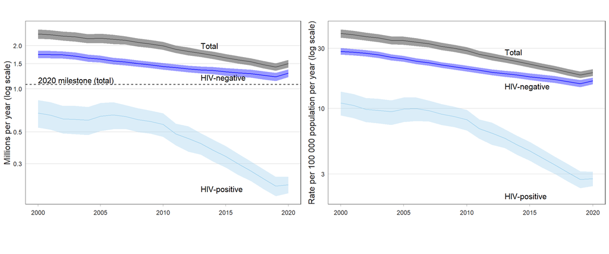

### Fig. 2.2.2 Top causes of death worldwide in 2019<sup>a,b</sup>

Deaths from TB among HIV-positive people are shown in grey.

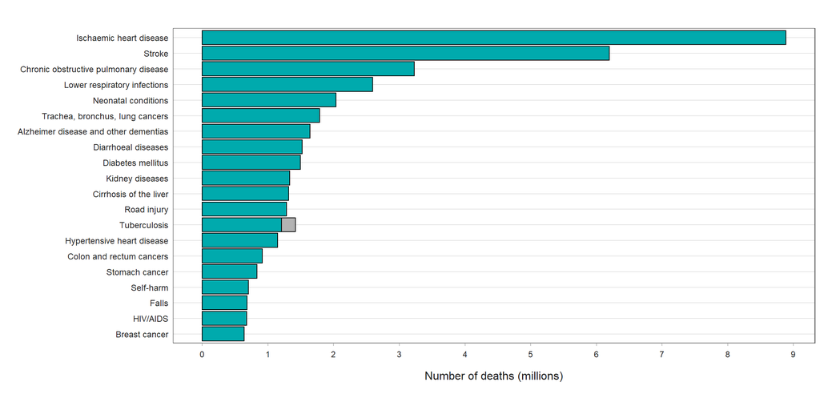

<sup>a</sup> This is the latest year for which estimates for all causes are currently available. See WHO estimates, available at https://www.who.int/data/gho/data/themes/mortality-and-global-health-estimates/ghe-leading-causes-of-death.  
<sup>b</sup> Deaths from TB among HIV-positive people are officially classified as deaths caused by HIV/AIDS in the International Classification of Diseases.

### Fig. 2.2.3 Estimated number of deaths from HIV/AIDS and TB in 2020<sup>a,b</sup>

Deaths from TB among HIV-positive people are shown in grey.

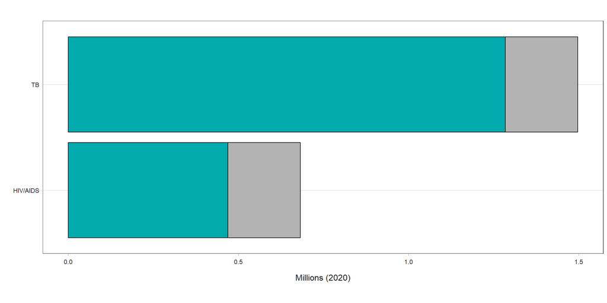

<sup>a</sup> For HIV/AIDS, the latest estimates of the number of deaths in 2020 that have been published by UNAIDS are available at http://www.unaids.org/en/ (accessed 16 August 2021). For TB, the estimates for 2020 are those published in this report.  
<sup>b</sup> Deaths from TB among HIV-positive people are officially classified as deaths caused by HIV/AIDS in the International Classification of Diseases.

### Fig. 2.2.4 Global trends in the estimated number of deaths caused by TB and HIV (in millions), 2000–2020<sup>a,b</sup>

Shaded areas represent uncertainty intervals.

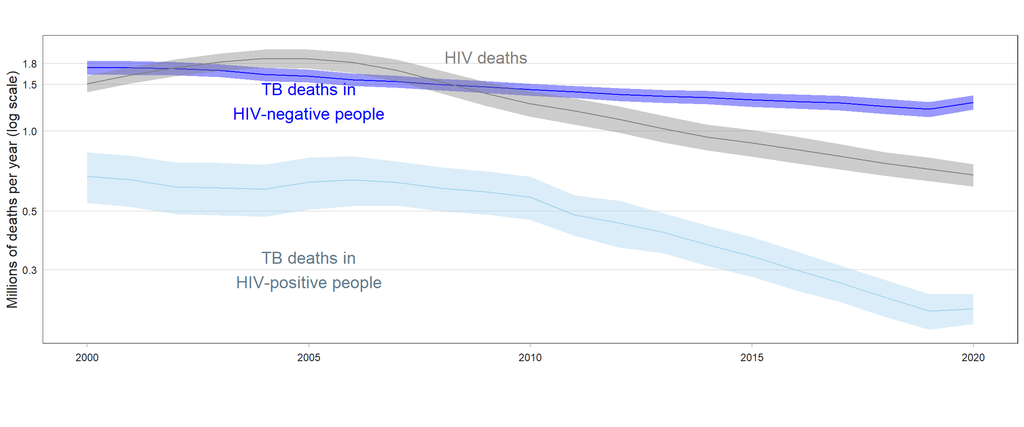

<sup>a</sup> For HIV/AIDS, the latest estimates of the number of deaths in 2020 that have been published by UNAIDS are available at http://www.unaids.org/en/ (accessed 16 August 2021). For TB, the estimates for 2020 are those published in this report.  
<sup>b</sup> Deaths from TB among HIV-positive people are officially classified as deaths caused by HIV/AIDS in the International Classification of Diseases.

### Fig. 2.2.5 Trends in estimated TB mortality rates by WHO region, 2000–2020

Estimated TB mortality rates among HIV-negative people are shown in blue and estimated mortality rates among HIV-positive people are shown in light blue. Shaded areas represent uncertainty intervals.

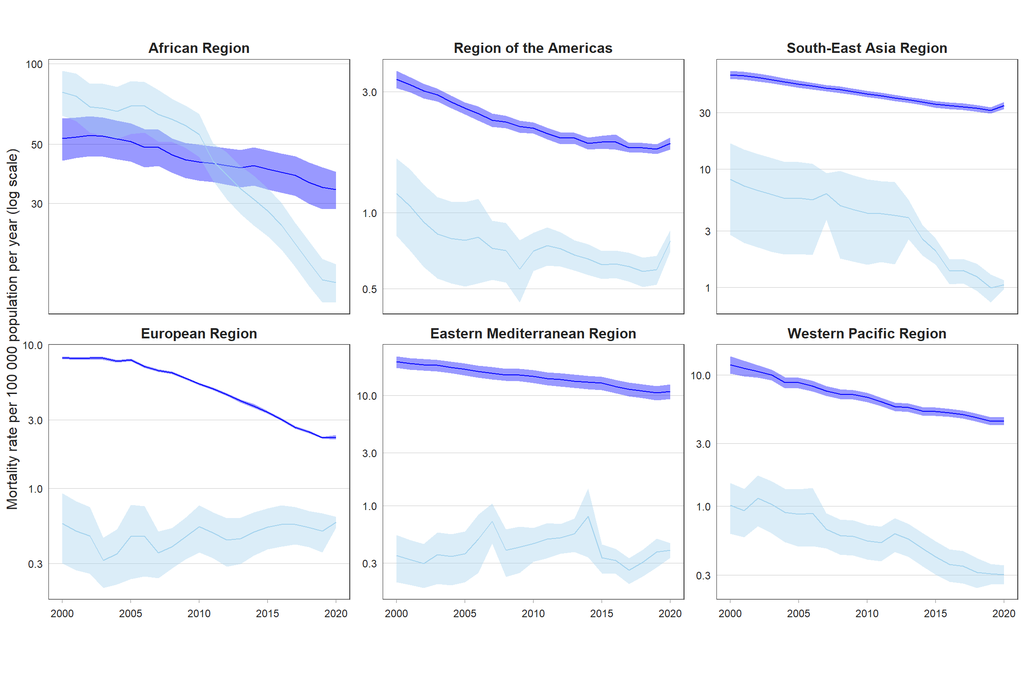

### Fig. 2.2.6 Trends in the estimated absolute number of TB deaths (HIV-positive and HIV-negative, in thousands) by WHO region, 2000–2020

Shaded areas represent uncertainty intervals. The horizontal dashed line shows the 2020 milestone of the End TB Strategy.

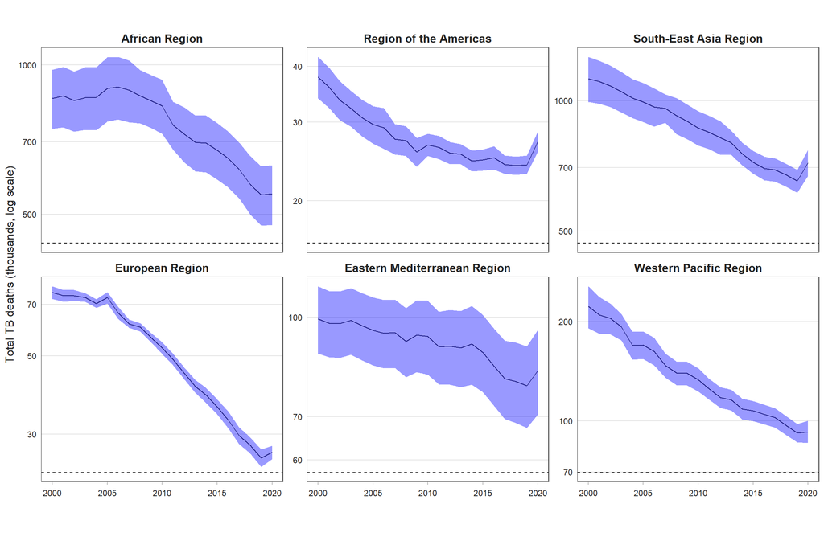

### Fig. 2.2.7a Trends in the estimated absolute number (in thousands) of TB deaths (HIV-positive and HIV-negative TB) in the 30 high TB burden countries, 2000–2020

Shaded areas represent uncertainty intervals. The horizontal dashed line shows the 2020 milestone of the End TB Strategy.

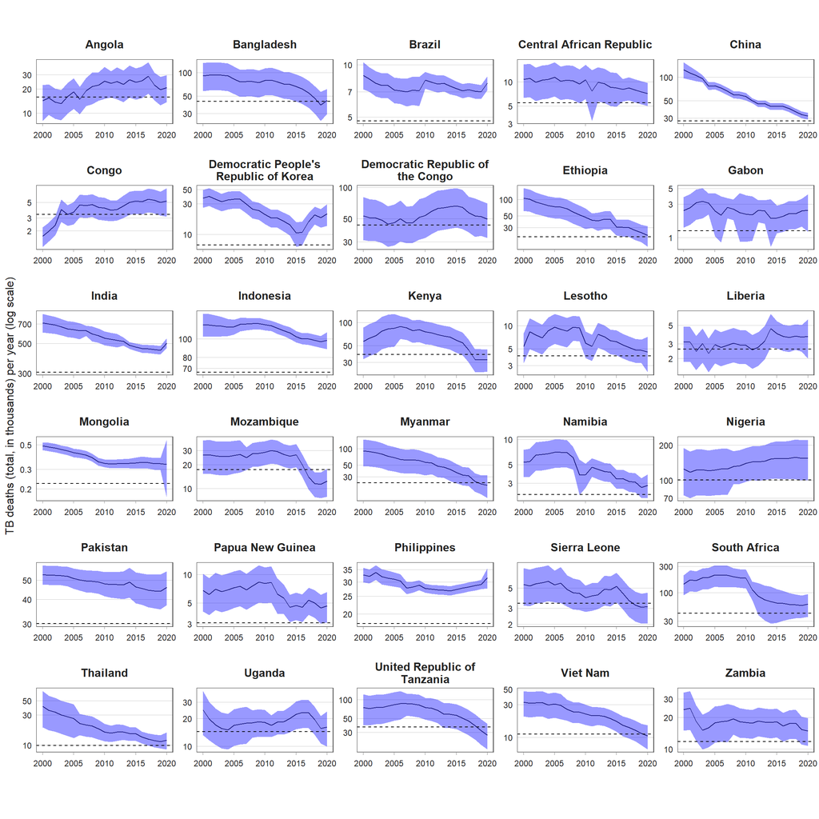

### Fig. 2.2.7b Trends in the estimated absolute number (in thousands) of TB deaths (HIV-positive and HIV-negative TB) in the 3 global TB watchlist countries, 2000–2020

Shaded areas represent uncertainty intervals. The horizontal dashed line shows the 2020 milestone of the End TB Strategy.

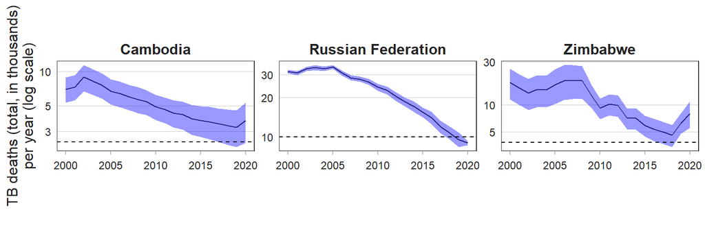

### Fig. 2.2.8 Estimated TB mortality rates in HIV-negative people, 2020

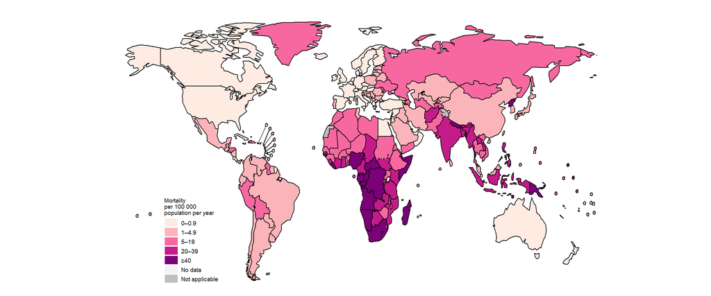

### Fig. 2.2.9 Estimates of the case fatality ratio (CFR), including HIV-negative and HIV-positive people, 2020

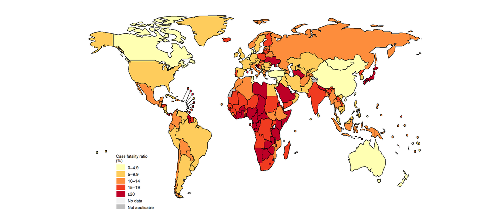

### Fig. 2.2.10a Global distribution of estimated TB mortality in HIV-negative people by age group and sex (female in purple; male in green), 2020

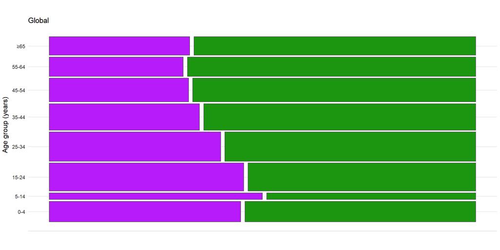

### Fig. 2.2.10b Regional distribution of estimated TB mortality in HIV-negative people by age group and sex (female in purple; male in green), 2020

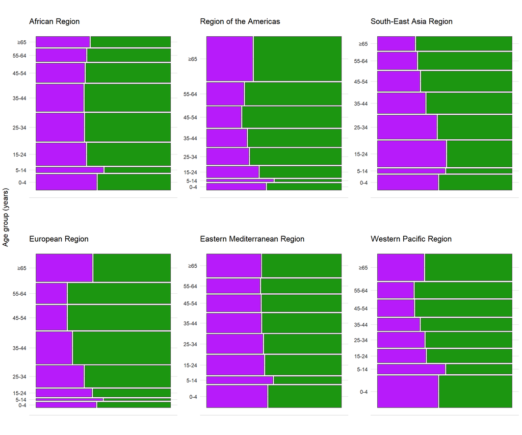

### Fig. 2.2.11a Main methods used to estimate TB mortality in HIV-negative people up to 2019

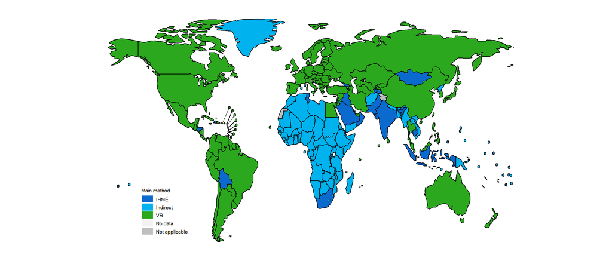

IHME: Institute of Health Metrics and Evaluation, Seattle, USA. VR: Vital registration of causes of deaths.

### Fig. 2.2.11b Main methods used to estimate TB mortality in HIV-negative people in 2020

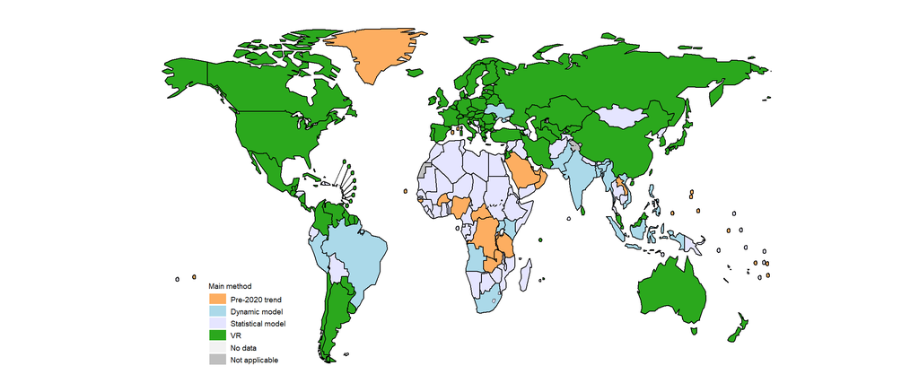

VR: Vital registration of causes of deaths.